# DATSCIW261 ASSIGNMENT #2

Jing Xu

jaling@gmail.com

W261-3

DATSCIW261 Assignment #2

1/23/16

**HW2.0 What is a race condition in the context of parallel computation? Give an example. What is MapReduce? How does it differ from Hadoop? Which programming paradigm is Hadoop based on? Explain and give a simple example in code and show the code running.**

Thread A: X = X + 1 Thread B: X = X + 1

Case 1: A and B both read initial value of X and overwrite each other, resulting in X = X + 1 Case 2: A reads and writes, then B reads and writes, resulting in X = X + 2

MapReduce is a Design Pattern in parallel computing for processing and generating large data sets with a parallel, distributed algorithm on a cluster. It involves two simple operations - Map and Reduce - that are applied to all elements of a sequence for primarily embarassingly parallel problems (problems that can be broken down into independent subtasks that require no communication or synchronization between the subtasks outside of a barrier or join at the end). The Map operation is sent to every node or processor, run on local data, and emits a key and value into temporary storage as a intermediary file. There is a shuffle step that sends all simiar keys to the same node, and then the Reduce step applies a function to the shuffled keys, for example a count.

While Hadoop is based on the functional programming paradigm of MapReduce, it differs in that Hadoop is a broader framework that has become the primary open-source implementation for MapReduce. Hadoop includes a distributed file system (HDFS), Avro (a data serialization system with scripting languages), Hive (a data summarization and ad hoc querying tool) on top of a MapReduce implementation. HDFS was developed to provide a single namespace for the cluster, handle data replication for fault tolerance, and was designed specifically to provide an efficient infrastructure for MapReduce jobs.

```python
%%writefile mapper.py
#!/usr/bin/python
## mapper.py
## Author: Jing Xu
## Description: mapper code for HW2.0

import sys
import re

WORD_RE = re.compile(r"[\w']+") #Compile regex to easily parse complete words

# read input from STDIN (standard input)
for line in sys.stdin:
    # remove leading and trailing whitespace
    line = line.strip()
    # split the line into words
    words=re.findall(WORD_RE,line) #create list of words
    words=words.lower()
    # increase counters
    for word in words:
        # write the results to STDOUT (standard output);
        # what we output here will be the input for the
        # Reduce step, i.e. the input for reducer.py
        # tab-delimited; the trivial word count is 1
        print '%s\t%s' % (word, 1)
```

```
Overwriting mapper.py
```

```python
%%writefile reducer.py
#!/usr/bin/python
## reducer.py
## Author: Jing Xu
## Description: reducer code for HW2.0

from operator import itemgetter
import sys
import re

current_word = None
current_count = 0
word = None

# input comes from STDIN
for line in sys.stdin:
    # remove leading and trailing whitespace
    line = line.strip()
    # parse the input we got from mapper.py
    word, count = line.split('\t', 1)
    # convert count (currently a string) to int
    try:
        count = int(count)
    except ValueError:
        # count was not a number, so silently
        # ignore/discard this line
        continue
    # this IF-switch only works because Hadoop sorts map output
    # by key (here: word) before it is passed to the reducer
    if current_word == word:
        current_count += count
    else:
        if current_word:
            # write result to STDOUT
            print '%s\t%s' % (current_word, current_count)
        current_count = count
        current_word = word

# do not forget to output the last word if needed!
if current_word == word:
    print '%s\t%s' % (current_word, current_count)
```

```
Overwriting reducer.py
```

```python
%%writefile mapreduce.sh
## mapreduce.sh
## Author: Jing Xu
## Description: mapreduce bash script for HW2.0

wget http://www.gutenberg.org/cache/epub/20417/pg20417.txt # download gutenberg text
wait

hdfs dfs -mkdir /user # create hdfs folder
wait
hdfs dfs -mkdir /user/jing # create hdfs folder
wait
hadoop fs -put pg20417.txt /user/jing # upload local file to hdfs folder
wait

# hadoop command to run streaming mapreduce job
hadoop jar /Users/JingXu/Documents/hadoop-2.6.3/share/hadoop/tools/lib/hadoop-streaming-2.6.3.jar \
-file mapper.py    -mapper mapper.py \
-file reducer.py   -reducer reducer.py \
-input /user/jing/* -output /user/jing/test-output1/
wait

hadoop fs -get /user/jing/test-output1/part-00000 part-00000
wait

cat part-00000 # print contents of the word count output file
wait

hdfs dfs -rmr /user/jing # remove hdfs folder
hdfs dfs -rmr /user # remove hdfs folder
rm part-00000 # delete results
rm pg20417.txt # delete gutenberg text
```

```
Overwriting mapreduce.sh
```

```python
# give correct permissions
!chmod a+x reducer.py
!chmod a+x mapper.py
!chmod a+x mapreduce.sh
```

```python
# run the mapreduce shell script to look at word count results
!./mapreduce.sh
```

[output not shown]

[output cut: 104 more lines]

[output not shown]

**HW2.1. Sort in Hadoop MapReduce**

**Given as input: Records of the form < integer, “NA” >, where integer is any integer, and “NA” is just the empty string. Output: sorted key value pairs of the form < integer, “NA” > in decreasing order; what happens if you have multiple reducers? Do you need additional steps? Explain.**

**Write code to generate N random records of the form < integer, “NA” >. Let N = 10,000. Write the python Hadoop streaming map-reduce job to perform this sort. Display the top 10 biggest numbers. Display the 10 smallest numbers**

```python
# Record generator script
from random import randint

i = 0 # count
N = 10000 # total random records
f = open('hw2-1','w') # open file to write
while i < N:
    num = randint(0,9999) # generate random integer between 0 - 10000
    f.write('%s, "NA"\n'%num) # write integer key and "NA" value to file
    i+=1
f.close() # close file
```

```python
%%writefile mapper.py
#!/usr/bin/python
## mapper.py
## Author: Jing Xu
## Description: mapper code for HW2.1

import sys
import re

# input comes from STDIN (standard input)
for line in sys.stdin:
    line = line.strip()
    print line
```

```
Overwriting mapper.py
```

```python
%%writefile reducer.py
#!/usr/bin/python
## reducer.py
## Author: Jing Xu
## Description: reducer code for HW2.1

from operator import itemgetter
import sys

current_word = None
current_count = 0
word = None

# input comes from STDIN
for line in sys.stdin:
    line = line.strip('\n')
    print line
```

```
Overwriting reducer.py
```

```python
%%writefile mapreduce.sh
## mapreduce.sh
## Author: Jing Xu
## Description: mapreduce bash script for HW2.1

# Upload file to hdfs
hdfs dfs -mkdir /user #create hdfs folder
wait
hdfs dfs -mkdir /user/jing #create hdfs folder
wait
hadoop fs -put hw2-1 /user/jing #upload local file to hdfs folder
wait

hadoop command to run streaming mapreduce job
hadoop jar /Users/JingXu/Documents/hadoop-2.6.3/share/hadoop/tools/lib/hadoop-streaming-2.6.3.jar \
-D mapred.output.key.comparator.class=org.apache.hadoop.mapred.lib.KeyFieldBasedComparator \
-D mapred.text.key.comparator.options=-n \
-D mapred.reduce.tasks=10 \
-file mapper.py    -mapper mapper.py \
-file reducer.py   -reducer reducer.py \
-input /user/jing/* -output /user/jing/test-output1/

#hadoop jar /Users/JingXu/Documents/hadoop-2.6.3/share/hadoop/tools/lib/hadoop-streaming-2.6.3.jar \
#    -D mapred.reduce.tasks=0 \
#    -file mapper.py -mapper mapper.py \
#    -input /user/jing/hw2-1 \
#    -output /user/jing/test-output1

wait

hadoop fs -get /user/jing/test-output1/part-00000 part-00000
hadoop fs -get /user/jing/test-output1/part-00009 part-00009
wait

tail -n 10 part-00009 #read first 10 lines of first reducer for the smallest numbers
head -n 10 part-00000 #read first 10 lines of first reducer for the smallest numbers
wait

hdfs dfs -rmr /user/jing #remove hdfs folder
hdfs dfs -rmr /user #remove hdfs folder
rm part-00000 #delete results
rm part-00009 #delete results
```

```
Overwriting mapreduce.sh
```

```python
# run the mapreduce shell script to look at word count results
!./mapreduce.sh
```

[output not shown]

[output cut: 428 more lines]

```
9929, "NA"
9930, "NA"
9965, "NA"
9990, "NA"
9990, "NA"
13, "NA"
31, "NA"
31, "NA"
37, "NA"
37, "NA"
48, "NA"
73, "NA"
73, "NA"
79, "NA"
91, "NA"
```

**10 Biggest Numbers:**

**10 Smallest Numbers:**

If there are x multiple reducers, the outputs on hdfs will be divided into x total outputs, and then to read the biggest numbers we will have to find the last output file and read the tail 10 lines, and to read the smallest numbers find the first output file and read the head 10 lines.

**HW2.2 WORDCOUNT Using the Enron data from HW1 and Hadoop MapReduce streaming, write the mapper/reducer job that will determine the word count (number of occurrences) of each white-space delimitted token (assume spaces, fullstops, comma as delimiters). Examine the word “assistance” and report its word count results.**

```python
%%writefile mapper.py
#!/usr/bin/python
## mapper.py
## Author: Jing Xu
## Description: mapper code for HW2.2

import sys
import re

WORD_RE = re.compile(r"[\w']+") # compile regex to easily parse complete words

# input comes from STDIN (standard input)
for line in sys.stdin:
    fields=line.split('\t') # parse line into separate fields
    subject_and_body=" ".join(fields[-2:]).strip()# parse the subject and body fields from the line, and combine into one string
    words=re.findall(WORD_RE,subject_and_body) # create list of words
    for word in words:
        print '%s\t%s' % (word, 1)
```

```
Overwriting mapper.py
```

```python
%%writefile reducer.py
#!/usr/bin/python
## reducer.py
## Author: Jing Xu
## Description: reducer code for HW2.2

from operator import itemgetter
import sys

current_word = None
current_count = 0
word = None

# input comes from STDIN
for line in sys.stdin:
    # remove leading and trailing whitespace
    line = line.strip()
    # parse the input we got from mapper.py
    word, count = line.split('\t', 1)
    # convert count (currently a string) to int
    try:
        count = int(count)
    except ValueError:
        # count was not a number, so silently
        # ignore/discard this line
        continue
    # this IF-switch only works because Hadoop sorts map output
    # by key (here: word) before it is passed to the reducer
    if current_word == word:
        current_count += count
    else:
        if current_word:
            # write result to STDOUT
            print '%s\t%s' % (current_word, current_count)
        current_count = count
        current_word = word

# do not forget to output the last word if needed!
if current_word == word:
    print '%s\t%s' % (current_word, current_count)
```

```
Overwriting reducer.py
```

```python
%%writefile mapreduce.sh
## mapreduce.sh
## Author: Jing Xu
## Description: mapreduce bash script for HW2.2

# Upload file to hdfs
hdfs dfs -mkdir /user #create hdfs folder
wait
hdfs dfs -mkdir /user/jing #create hdfs folder
wait
hadoop fs -put enronemail_1h.txt /user/jing #upload local file to hdfs folder
wait

#hadoop command to run streaming mapreduce job
hadoop jar /Users/JingXu/Documents/hadoop-2.6.3/share/hadoop/tools/lib/hadoop-streaming-2.6.3.jar \
-file mapper.py    -mapper mapper.py \
-file reducer.py   -reducer reducer.py \
-input /user/jing/* -output /user/jing/test-output1/
wait

hadoop fs -get /user/jing/test-output1/part-00000 part-00000
wait

cat part-00000 #print contents of the word count output file
wait

hdfs dfs -rmr /user/jing #remove hdfs folder
hdfs dfs -rmr /user #remove hdfs folder
rm part-00000 #delete results
```

```
Overwriting mapreduce.sh
```

```python
# run the mapreduce shell script to look at word count results
!./mapreduce.sh
```

[output not shown]

[output cut: 5590 more lines]

```
zesto	10
zimin	5
zinc	1
zk	1
zo	2
zolam	2
zxs	1
rmr: DEPRECATED: Please use 'rm -r' instead.
16/01/26 06:10:35 WARN util.NativeCodeLoader: Unable to load native-hadoop library for your platform... using builtin-java classes where applicable
16/01/26 06:10:35 INFO fs.TrashPolicyDefault: Namenode trash configuration: Deletion interval = 0 minutes, Emptier interval = 0 minutes.
Deleted /user/jing
rmr: DEPRECATED: Please use 'rm -r' instead.
16/01/26 06:10:36 WARN util.NativeCodeLoader: Unable to load native-hadoop library for your platform... using builtin-java classes where applicable
16/01/26 06:10:37 INFO fs.TrashPolicyDefault: Namenode trash configuration: Deletion interval = 0 minutes, Emptier interval = 0 minutes.
Deleted /user
```

"assistance" has 10 occurrences

**HW2.3. Multinomial NAIVE BAYES with NO Smoothing Using the Enron data from HW1 and Hadoop MapReduce, write a mapper/reducer job(s) that will both learn Naive Bayes classifier and classify the Enron email messages using the learnt Naive Bayes classifier. Use all white-space delimitted tokens as independent input variables (assume spaces, fullstops, commas as delimiters). Note: for multinomial Naive Bayes, the Pr(X=“assistance”|Y=SPAM) is calculated as follows:**

**the number of times “assistance” occurs in SPAM labeled documents / the number of words in documents labeled SPAM**

**E.g., “assistance” occurs 5 times in all of the documents Labeled SPAM, and the length in terms of the number of words in all documents labeled as SPAM (when concatenated) is 1,000. Then Pr(X=“assistance”|Y=SPAM) = 5/1000. Note this is a multinomial estimation of the class conditional for a Naive Bayes Classifier. No smoothing is needed in this HW. Multiplying lots of probabilities, which are between 0 and 1, can result in floating-point underflow. Since log(xy) = log(x) + log(y), it is better to perform all computations by summing logs of probabilities rather than multiplying probabilities. Please pay attention to probabilites that are zero! They will need special attention. Count up how many times you need to process a zero probabilty for each class and report.**

**Report the performance of your learnt classifier in terms of misclassifcation error rate of your multinomial Naive Bayes Classifier. Plot a histogram of the log posterior probabilities (i.e., log(Pr(Class|Doc))) for each class over the training set. Summarize what you see.**

**Error Rate = misclassification rate with respect to a provided set (say training set in this case). It is more formally defined here:**

**Let DF represent the evalution set in the following: Err(Model, DF) = |{(X, c(X)) ∈ DF : c(X) != Model(x)}| / |DF|**

**Where || denotes set cardinality; c(X) denotes the class of the tuple X in DF; and Model(X) denotes the class inferred by the Model “Model”**

```python
%%writefile mapper.py
#!/usr/bin/python
#HW 2.3 - Mapper function
#This mapper function will send one line for every instance of every word to the reducer. This approach, while easier to write and debug, is unlikely to be the best choice for a larger scale implementation because of the large volume of data that would have to be sent to the reducers. A potentially more-streamlined alternative would be to add a "combiner" step at the end of the mapper that would send one line for each word-email combination (E.G. Key:email-word-flag, Value:count).
#In addition, if we only care about generating the conditional probabilities for each word and don't need to classify all the training emails, we could simplify the implementation even more and not send the email contents themselves to the reducer. Not only would this decrease throughput, but it would also dramatically reduce the amount of information that the reducer would need to store in memory. In this situation, our mapper could simply emit words along with their conditional class counts. I have not implemented this in this homework, but we'll want to keep this in mind for the future.

import sys
import re

WORD_RE = re.compile(r"[\w']+") #Compile regex to easily parse complete words

for line in sys.stdin:
    fields=line.split('\t') #parse line into separate fields
    if len(fields) == 4: #check if email data formatted correctly
        subject_and_body=" ".join(fields[-2:]).strip()#parse the subject and body fields from the line, and combine into one string
        words=re.findall(WORD_RE,subject_and_body) #create list of words
        for word in words:
            #This will send one row for every word instance to the reducer.
            print fields[0]+'\t'+fields[1]+'\t'+word
```

```
Overwriting mapper.py
```

```python
%%writefile reducer.py
#!/usr/bin/python
#HW 2.3 - Reducer function
#The reducer maintains two associative arrays.
#The first stores information about each word, including how
#many times it appears in spam and ham messages, as well as if it's been flagged in the mapper.
#The  second stores information about emails, including whether it is marked as spam, as well as a list of
#words it contains.
#Once all the data has arrived from the mappers, the array containing words is updated with the calculated
#conditional probabilities of spam and ham. At this point, the model is "trained". Finally, these
#conditional probabilities are reapplied to the word lists associated with each email to make the
#final spam/ham classification as an output file. There is also a count for each zero probability calculation
#for each class.

from __future__ import division #Python 3-style division syntax is much cleaner
import sys
from math import log

words={}
emails={}
spam_email_count=0 #number of emails marked as spam
spam_word_count=0 #number of total (not unique) words in spam emails
ham_word_count=0 #number of total (not unique) words in ham emails
for line in sys.stdin:
    #parse the incoming line
    result=line.split("\t")
    email=result[0]
    spam=int(result[1])
    word=result[2]
    #initialize storage for word/email data
    if word not in words.keys():
        words[word]={'ham_count':0,'spam_count':0}
    if email not in emails.keys():
        emails[email]={'spam':spam,'word_count':0,'words':[]}
        if spam==1:
            spam_email_count+=1
    #store word data
    if spam==1:
        words[word]['spam_count']+=1
        spam_word_count+=1
    else:
        words[word]['ham_count']+=1
        ham_word_count+=1
    #store email data
    emails[email]['words'].append(word)
    emails[email]['word_count']+=1

#Calculate stats for entire corpus
prior_spam=spam_email_count/len(emails)
prior_ham=1-prior_spam
vocab_count=len(words)#number of unique words in the total vocabulary
spam_zero_prob_count = 0 #count of number of zero probability words for all spam emails
ham_zero_prob_count = 0 #count of number of zero probability words for all spam emails

for k,word in words.iteritems():
    #Compute conditional probabilities WITHOUT Laplace smoothing
    word['p_spam']=(word['spam_count'])/(spam_word_count)
    if word['p_spam']==0: spam_zero_prob_count+=1
    word['p_ham']=(word['ham_count'])/(ham_word_count)
    if word['p_ham']==0: ham_zero_prob_count+=1

correct_predictions = 0
incorrect_predictions = 0
spam_log_posterior_probabilities = [] #keep list of p_spam probabilities for histogram
ham_log_posterior_probabilities = [] #keep list of p_ham probabilities for histogram

#At this point the model is now trained, and we can use it to make our predictions
for j,email in emails.iteritems():
    p_spam=log(prior_spam) #log of prior_spam
    p_ham=log(prior_ham) #log of prior_ham
    for word in email['words']:
        if words[word]['p_spam'] != 0 and words[word]['p_ham'] != 0: #exclude conditional probabilities for any word where count = 0 for either classification
            try:
                p_spam+=log(words[word]['p_spam']) #log version calculation of p_spam
            except ValueError:
                continue #This means that words that do not appear in a class will use the class prior
            try:
                p_ham+=log(words[word]['p_ham']) #log version calculation of p_ham
            except ValueError:
                continue
    if p_spam>p_ham: #predict class
        spam_pred=1
    else:
        spam_pred=0
    spam_log_posterior_probabilities.append(p_spam)
    ham_log_posterior_probabilities.append(p_ham)
    print j+'\t'+str(email['spam'])+'\t'+str(spam_pred) #emit true class and class predictions for email
    if str(email['spam']) == str(spam_pred): correct_predictions+=1 #count correct predictions
    else: incorrect_predictions+=1 #count incorrect predictions

print "error rate"+'\t'+str(incorrect_predictions/(incorrect_predictions+correct_predictions))
print "spam zero probability count"+'\t'+str(spam_zero_prob_count)
print "ham zero probability count"+'\t'+str(ham_zero_prob_count)
print "spam_log_posterior_probabilities"+'\t'+str(spam_log_posterior_probabilities)
print "ham_log_posterior_probabilities"+'\t'+str(ham_log_posterior_probabilities)
```

```
Overwriting reducer.py
```

```python
%%writefile mapreduce.sh
## mapreduce.sh
## Author: Jing Xu
## Description: mapreduce bash script for HW2.2

hdfs dfs -mkdir /user #create hdfs folder
wait
hdfs dfs -mkdir /user/jing #create hdfs folder
wait
hadoop fs -put enronemail_1h.txt /user/jing #upload local file to hdfs folder
wait

#hadoop streaming mapreduce command
hadoop jar /Users/JingXu/Documents/hadoop-2.6.3/share/hadoop/tools/lib/hadoop-streaming-2.6.3.jar \
-file mapper.py    -mapper mapper.py \
-file reducer.py   -reducer reducer.py \
-input /user/jing/* -output /user/jing/test-output1/

hadoop fs -get /user/jing/test-output1/part-00000 hw2-3results #download hw2-3results to local
wait

hdfs dfs -rmr /user/jing #remove hdfs folder
hdfs dfs -rmr /user #remove hdfs folder
#rm hw2-3results #delete results
```

```
Overwriting mapreduce.sh
```

```python
!./mapreduce.sh
```

[output not shown]

[output cut: 101 more lines]

[output not shown]

```python
%matplotlib inline
```

```
error rate: 0.102040816327

spam zero probability count: 1674

ham zero probability count: 2727
```

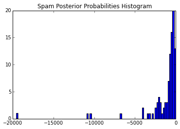

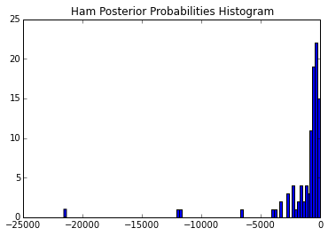

```python
import matplotlib.pyplot as plt #

#read results of mapreduce job
results = open('hw2-3results', "r")

spam_log_posterior_probabilities = [] #keep list of p_spam probabilities for histogram
ham_log_posterior_probabilities = [] #keep list of p_ham probabilities for histogram

sp = []
hp = []

for line in results.readlines():
    result=line.split("\t")
    if result[0] == 'error rate':
        print 'error rate:', result[1]
    elif result[0] == 'spam zero probability count':
        print 'spam zero probability count:', result[1]
    elif result[0] == 'ham zero probability count':
        print 'ham zero probability count:', result[1]
    elif result[0] == 'spam_log_posterior_probabilities':
        spam_log_posterior_probabilities = result[1]
    elif result[0] == 'ham_log_posterior_probabilities':
        ham_log_posterior_probabilities = result[1]

spam_log_posterior_probabilities = spam_log_posterior_probabilities.strip()
spam_log_posterior_probabilities = spam_log_posterior_probabilities.strip('[')
spam_log_posterior_probabilities = spam_log_posterior_probabilities.strip(']')
spam_log_posterior_probabilities = spam_log_posterior_probabilities.split(',')
for value in spam_log_posterior_probabilities:
    sp.append(float(value))
ham_log_posterior_probabilities = ham_log_posterior_probabilities.strip()
ham_log_posterior_probabilities = ham_log_posterior_probabilities.strip('[')
ham_log_posterior_probabilities = ham_log_posterior_probabilities.strip(']')
ham_log_posterior_probabilities = ham_log_posterior_probabilities.split(',')
for value in ham_log_posterior_probabilities:
    hp.append(float(value))

plt.hist(sp, bins=100)
plt.title("Spam Posterior Probabilities Histogram")
plt.show()

plt.hist(hp, bins=100)
plt.title("Ham Posterior Probabilities Histogram")
plt.show()
```

The histogram for both spam and ham displays heavy skew towards 0 with a few outlier cases.

**HW2.4 Repeat HW2.3 with the following modification: use Laplace plus-one smoothing. Compare the misclassifcation error rates for 2.3 versus 2.4 and explain the differences.**

```python
%%writefile mapper.py
#!/usr/bin/python
#HW 2.4 - Mapper function
#This mapper function will send one line for every instance of every word to the reducer. This approach, while easier to write and debug, is unlikely to be the best choice for a larger scale implementation because of the large volume of data that would have to be sent to the reducers. A potentially more-streamlined alternative would be to add a "combiner" step at the end of the mapper that would send one line for each word-email combination (E.G. Key:email-word-flag, Value:count).
#In addition, if we only care about generating the conditional probabilities for each word and don't need to classify all the training emails, we could simplify the implementation even more and not send the email contents themselves to the reducer. Not only would this decrease throughput, but it would also dramatically reduce the amount of information that the reducer would need to store in memory. In this situation, our mapper could simply emit words along with their conditional class counts. I have not implemented this in this homework, but we'll want to keep this in mind for the future.

import sys
import re

WORD_RE = re.compile(r"[\w']+") #Compile regex to easily parse complete words

for line in sys.stdin:
    fields=line.split('\t') #parse line into separate fields
    if len(fields) == 4: #check if email data formatted correctly
        subject_and_body=" ".join(fields[-2:]).strip()#parse the subject and body fields from the line, and combine into one string
        words=re.findall(WORD_RE,subject_and_body) #create list of words
        for word in words:
            #This will send one row for every word instance to the reducer.
            print fields[0]+'\t'+fields[1]+'\t'+word
```

```
Overwriting mapper.py
```

```python
%%writefile reducer.py
#!/usr/bin/python
#HW 2.4 - Reducer function
#The reducer maintains two associative arrays.
#The first stores information about each word, including how
#many times it appears in spam and ham messages, as well as if it's been flagged in the mapper.
#The  second stores information about emails, including whether it is marked as spam, as well as a list of
#words it contains.
#Once all the data has arrived from the mappers, the array containing words is updated with the calculated
#conditional probabilities of spam and ham. At this point, the model is "trained". Finally, these
#conditional probabilities are reapplied to the word lists associated with each email to make the
#final spam/ham classification as an output file. There is also a count for each zero probability calculation
#for each class.

from __future__ import division #Python 3-style division syntax is much cleaner
import sys
from math import log

words={}
emails={}
spam_email_count=0 #number of emails marked as spam
spam_word_count=0 #number of total (not unique) words in spam emails
ham_word_count=0 #number of total (not unique) words in ham emails
for line in sys.stdin:
    #parse the incoming line
    result=line.split("\t")
    email=result[0]
    spam=int(result[1])
    word=result[2]
    #initialize storage for word/email data
    if word not in words.keys():
        words[word]={'ham_count':0,'spam_count':0}
    if email not in emails.keys():
        emails[email]={'spam':spam,'word_count':0,'words':[]}
        if spam==1:
            spam_email_count+=1
    #store word data
    if spam==1:
        words[word]['spam_count']+=1
        spam_word_count+=1
    else:
        words[word]['ham_count']+=1
        ham_word_count+=1
    #store email data
    emails[email]['words'].append(word)
    emails[email]['word_count']+=1

#Calculate stats for entire corpus
prior_spam=spam_email_count/len(emails)
prior_ham=1-prior_spam
vocab_count=len(words)#number of unique words in the total vocabulary
spam_zero_prob_count = 0 #count of number of zero probability words for all spam emails
ham_zero_prob_count = 0 #count of number of zero probability words for all spam emails

for k,word in words.iteritems():
    #Compute conditional probabilities WITH Laplace smoothing
    word['p_spam']=(word['spam_count']+1)/(spam_word_count+vocab_count) #add 1 to numerator, vocab_count to denominator
    if word['p_spam']==0: spam_zero_prob_count+=1
    word['p_ham']=(word['ham_count']+1)/(ham_word_count+vocab_count) #add 1 to numerator, vocab_count to denominator
    if word['p_ham']==0: ham_zero_prob_count+=1

correct_predictions = 0
incorrect_predictions = 0
spam_log_posterior_probabilities = [] #keep list of p_spam probabilities for histogram
ham_log_posterior_probabilities = [] #keep list of p_ham probabilities for histogram

#At this point the model is now trained, and we can use it to make our predictions
for j,email in emails.iteritems():
    p_spam=log(prior_spam) #log of prior_spam
    p_ham=log(prior_ham) #log of prior_ham
    for word in email['words']:
        if words[word]['spam_count'] != 0 and words[word]['ham_count'] != 0: #exclude conditional probabilities for any word where count = 0 for either classification
            try:
                p_spam+=log(words[word]['p_spam']) #log version calculation of p_spam
            except ValueError:
                continue #This means that words that do not appear in a class will use the class prior
            try:
                p_ham+=log(words[word]['p_ham']) #log version calculation of p_ham
            except ValueError:
                continue
    if p_spam>p_ham: #predict class
        spam_pred=1
    else:
        spam_pred=0
    spam_log_posterior_probabilities.append(p_spam)
    ham_log_posterior_probabilities.append(p_ham)
    print j+'\t'+str(email['spam'])+'\t'+str(spam_pred) #emit true class and class predictions for email
    if str(email['spam']) == str(spam_pred): correct_predictions+=1 #count correct predictions
    else: incorrect_predictions+=1 #count incorrect predictions

print "error rate"+'\t'+str(incorrect_predictions/(incorrect_predictions+correct_predictions))
print "spam zero probability count"+'\t'+str(spam_zero_prob_count)
print "ham zero probability count"+'\t'+str(ham_zero_prob_count)
print "spam_log_posterior_probabilities"+'\t'+str(spam_log_posterior_probabilities)
print "ham_log_posterior_probabilities"+'\t'+str(ham_log_posterior_probabilities)
```

```
Overwriting reducer.py
```

```python
%%writefile mapreduce.sh
## mapreduce.sh
## Author: Jing Xu
## Description: mapreduce bash script for HW2.2

hdfs dfs -mkdir /user #create hdfs folder
wait
hdfs dfs -mkdir /user/jing #create hdfs folder
wait
hadoop fs -put enronemail_1h.txt /user/jing #upload local file to hdfs folder
wait

#hadoop streaming mapreduce command
hadoop jar /Users/JingXu/Documents/hadoop-2.6.3/share/hadoop/tools/lib/hadoop-streaming-2.6.3.jar \
-file mapper.py    -mapper mapper.py \
-file reducer.py   -reducer reducer.py \
-input /user/jing/* -output /user/jing/test-output1/

hadoop fs -get /user/jing/test-output1/part-00000 hw2-4results #download hw2-4results to local
wait

hdfs dfs -rmr /user/jing #remove hdfs folder
hdfs dfs -rmr /user #remove hdfs folder
```

```
Overwriting mapreduce.sh
```

```python
!./mapreduce.sh
```

[output not shown]

[output cut: 101 more lines]

[output not shown]

```
error rate: 0.122448979592

spam zero probability count: 0

ham zero probability count: 0
```

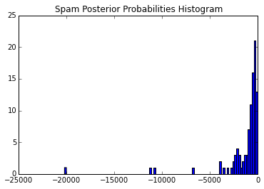

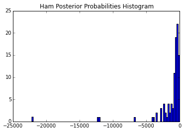

```python
import matplotlib.pyplot as plt #

#read results of mapreduce job
results = open('hw2-4results', "r")

spam_log_posterior_probabilities = [] #keep list of p_spam probabilities for histogram
ham_log_posterior_probabilities = [] #keep list of p_ham probabilities for histogram

sp = []
hp = []

for line in results.readlines():
    result=line.split("\t")
    if result[0] == 'error rate':
        print 'error rate:', result[1]
    elif result[0] == 'spam zero probability count':
        print 'spam zero probability count:', result[1]
    elif result[0] == 'ham zero probability count':
        print 'ham zero probability count:', result[1]
    elif result[0] == 'spam_log_posterior_probabilities':
        spam_log_posterior_probabilities = result[1]
    elif result[0] == 'ham_log_posterior_probabilities':
        ham_log_posterior_probabilities = result[1]

spam_log_posterior_probabilities = spam_log_posterior_probabilities.strip()
spam_log_posterior_probabilities = spam_log_posterior_probabilities.strip('[')
spam_log_posterior_probabilities = spam_log_posterior_probabilities.strip(']')
spam_log_posterior_probabilities = spam_log_posterior_probabilities.split(',')
for value in spam_log_posterior_probabilities:
    sp.append(float(value))
ham_log_posterior_probabilities = ham_log_posterior_probabilities.strip()
ham_log_posterior_probabilities = ham_log_posterior_probabilities.strip('[')
ham_log_posterior_probabilities = ham_log_posterior_probabilities.strip(']')
ham_log_posterior_probabilities = ham_log_posterior_probabilities.split(',')
for value in ham_log_posterior_probabilities:
    hp.append(float(value))

plt.hist(sp, bins=100)
plt.title("Spam Posterior Probabilities Histogram")
plt.show()

plt.hist(hp, bins=100)
plt.title("Ham Posterior Probabilities Histogram")
plt.show()
```

The misclassification error for HW2.4 is .122449, compared to .102041 for HW2.3. This is due to Laplace Smoothing being added to prevent overfitting - it is used to smooth categorical data, but also has the effect of increasing bias as shown here in the higher error rate.

**HW2.5. Repeat HW2.4. This time when modeling and classification ignore tokens with a frequency of less than three (3) in the training set. How does it affect the misclassifcation error of learnt naive multinomial Bayesian Classifier on the training dataset:**

```python
%%writefile mapper.py
#!/usr/bin/python
## mapper.py
## Author: Jing Xu
## Description: mapper count code for HW2.5. Generate a wordcount list from the enron email dataset
## and filter out all strings with a count < 3.
import sys
import re

WORD_RE = re.compile(r"[\w']+") # compile regex to easily parse complete words

# input comes from STDIN (standard input)
for line in sys.stdin:
    fields=line.split('\t') # parse line into separate fields
    if len(fields) == 4: #check if email data formatted correctly
        subject_and_body=" ".join(fields[-2:]).strip()# parse the subject and body fields from the line, and combine into one string
        words=re.findall(WORD_RE,subject_and_body) # create list of words
        for word in words:
            print '%s\t%s' % (word, 1)
```

```
Overwriting mapper.py
```

```python
%%writefile reducer.py
#!/usr/bin/python
## reducer.py
## Author: Jing Xu
## Description: reducer code for HW2.5. Generate a wordcount list from the enron email dataset

from operator import itemgetter
import sys

current_word = None
current_count = 0
word = None

# input comes from STDIN
for line in sys.stdin:
    # remove leading and trailing whitespace
    line = line.strip()
    # parse the input we got from mapper.py
    word, count = line.split('\t', 1)
    # convert count (currently a string) to int
    try:
        count = int(count)
    except ValueError:
        # count was not a number, so silently
        # ignore/discard this line
        continue
    # this IF-switch only works because Hadoop sorts map output
    # by key (here: word) before it is passed to the reducer
    if current_word == word:
        current_count += count
    else:
        if current_word:
            # write result to STDOUT
            print '%s\t%s' % (current_word, current_count)
        current_count = count
        current_word = word

# do not forget to output the last word if needed!
if current_word == word:
    print '%s\t%s' % (current_word, current_count)
```

```
Overwriting reducer.py
```

```python
%%writefile mapreduce.sh
## mapreduce.sh
## Author: Jing Xu
## Description: mapreduce bash script for HW2.2

# Upload file to hdfs
hdfs dfs -mkdir /user #create hdfs folder
wait
hdfs dfs -mkdir /user/jing #create hdfs folder
wait
hadoop fs -put enronemail_1h.txt /user/jing #upload local file to hdfs folder
wait

#hadoop command to run streaming mapreduce job
hadoop jar /Users/JingXu/Documents/hadoop-2.6.3/share/hadoop/tools/lib/hadoop-streaming-2.6.3.jar \
-file mapper.py    -mapper mapper.py \
-file reducer.py   -reducer reducer.py \
-input /user/jing/* -output /user/jing/test-output1/
wait

hadoop fs -get /user/jing/test-output1/part-00000 enron_word_count
wait

hdfs dfs -rmr /user/jing #remove hdfs folder
hdfs dfs -rmr /user #remove hdfs folder
```

```
Overwriting mapreduce.sh
```

```python
!./mapreduce.sh
```

[output not shown]

[output cut: 100 more lines]

[output not shown]

```python
#open enron_word_count, delete lines with count < 3, save remaining words to file allowed_words
enron_word_count = open('enron_word_count', "r")
allowed_words = []
for line in enron_word_count.readlines():
    line=line.split("\t")
    if int(line[1]) > 2: allowed_words.append(line[0]) #if count > 2, append to allowed_words list

with open('allowed_words', 'w') as thefile:
    for item in allowed_words:
        thefile.write("%s\n" %item) #write allowed_words to file
```

```python
%%writefile mapper.py
#!/usr/bin/python
#HW 2.5 - Mapper function
#This mapper function will send one line for every instance of every word to the reducer.

import sys
sys.path.append('.')
import re

WORD_RE = re.compile(r"[\w']+") #Compile regex to easily parse complete words

allowed_words = []

thefile = open('allowed_words', 'r')
for line in thefile:
    line = line.strip()
    allowed_words.append(line)

for line in sys.stdin:
    fields=line.split('\t') #parse line into separate fields
    if len(fields) == 4: #check if email data formatted correctly
        subject_and_body=" ".join(fields[-2:]).strip()#parse the subject and body fields from the line, and combine into one string
        words=re.findall(WORD_RE,subject_and_body) #create list of words
        for word in words:
            #This flag indicates to the reducer that a given word should be considered
            #by the reducer when calculating the conditional probabilities
            if word in allowed_words:
                #This will send one row for every word instance to the reducer.
                print fields[0]+'\t'+fields[1]+'\t'+word
```

```
Overwriting mapper.py
```

```python
%%writefile reducer.py
#!/usr/bin/python
#HW 2.4 - Reducer function
#The reducer maintains two associative arrays.
#The first stores information about each word, including how
#many times it appears in spam and ham messages, as well as if it's been flagged in the mapper.
#The  second stores information about emails, including whether it is marked as spam, as well as a list of
#words it contains.
#Once all the data has arrived from the mappers, the array containing words is updated with the calculated
#conditional probabilities of spam and ham. At this point, the model is "trained". Finally, these
#conditional probabilities are reapplied to the word lists associated with each email to make the
#final spam/ham classification as an output file. There is also a count for each zero probability calculation
#for each class.

from __future__ import division #Python 3-style division syntax is much cleaner
import sys
from math import log

words={}
emails={}
spam_email_count=0 #number of emails marked as spam
spam_word_count=0 #number of total (not unique) words in spam emails
ham_word_count=0 #number of total (not unique) words in ham emails
for line in sys.stdin:
    #parse the incoming line
    result=line.split("\t")
    email=result[0]
    spam=int(result[1])
    word=result[2]
    #initialize storage for word/email data
    if word not in words.keys():
        words[word]={'ham_count':0,'spam_count':0}
    if email not in emails.keys():
        emails[email]={'spam':spam,'word_count':0,'words':[]}
        if spam==1:
            spam_email_count+=1
    #store word data
    if spam==1:
        words[word]['spam_count']+=1
        spam_word_count+=1
    else:
        words[word]['ham_count']+=1
        ham_word_count+=1
    #store email data
    emails[email]['words'].append(word)
    emails[email]['word_count']+=1

#Calculate stats for entire corpus
prior_spam=spam_email_count/len(emails)
prior_ham=1-prior_spam
vocab_count=len(words)#number of unique words in the total vocabulary
spam_zero_prob_count = 0 #count of number of zero probability words for all spam emails
ham_zero_prob_count = 0 #count of number of zero probability words for all spam emails

for k,word in words.iteritems():
    #Compute conditional probabilities WITH Laplace smoothing
    word['p_spam']=(word['spam_count']+1)/(spam_word_count+vocab_count) #add 1 to numerator, vocab_count to denominator
    if word['p_spam']==0: spam_zero_prob_count+=1
    word['p_ham']=(word['ham_count']+1)/(ham_word_count+vocab_count) #add 1 to numerator, vocab_count to denominator
    if word['p_ham']==0: ham_zero_prob_count+=1

correct_predictions = 0
incorrect_predictions = 0
spam_log_posterior_probabilities = [] #keep list of p_spam probabilities for histogram
ham_log_posterior_probabilities = [] #keep list of p_ham probabilities for histogram

#At this point the model is now trained, and we can use it to make our predictions
for j,email in emails.iteritems():
    p_spam=log(prior_spam) #log of prior_spam
    p_ham=log(prior_ham) #log of prior_ham
    for word in email['words']:
        if words[word]['spam_count'] != 0 and words[word]['ham_count'] != 0: #exclude conditional probabilities for any word where count = 0 for either classification
            try:
                p_spam+=log(words[word]['p_spam']) #log version calculation of p_spam
            except ValueError:
                continue #This means that words that do not appear in a class will use the class prior
            try:
                p_ham+=log(words[word]['p_ham']) #log version calculation of p_ham
            except ValueError:
                continue
    if p_spam>p_ham: #predict class
        spam_pred=1
    else:
        spam_pred=0
    spam_log_posterior_probabilities.append(p_spam)
    ham_log_posterior_probabilities.append(p_ham)
    print j+'\t'+str(email['spam'])+'\t'+str(spam_pred) #emit true class and class predictions for email
    if str(email['spam']) == str(spam_pred): correct_predictions+=1 #count correct predictions
    else: incorrect_predictions+=1 #count incorrect predictions

print "error rate"+'\t'+str(incorrect_predictions/(incorrect_predictions+correct_predictions))
print "spam zero probability count"+'\t'+str(spam_zero_prob_count)
print "ham zero probability count"+'\t'+str(ham_zero_prob_count)
print "spam_log_posterior_probabilities"+'\t'+str(spam_log_posterior_probabilities)
print "ham_log_posterior_probabilities"+'\t'+str(ham_log_posterior_probabilities)
```

```
Overwriting reducer.py
```

```python
%%writefile mapreduce.sh
## mapreduce.sh
## Author: Jing Xu
## Description: mapreduce bash script for HW2.5

hdfs dfs -mkdir /user #create hdfs folder
wait
hdfs dfs -mkdir /user/jing #create hdfs folder
wait
hadoop fs -put enronemail_1h.txt /user/jing #upload local file to hdfs folder
wait

#hadoop streaming mapreduce command
hadoop jar /Users/JingXu/Documents/hadoop-2.6.3/share/hadoop/tools/lib/hadoop-streaming-2.6.3.jar \
-file mapper.py    -mapper mapper.py \
-file reducer.py   -reducer reducer.py \
-input /user/jing/* -output /user/jing/test-output1/ -file 'allowed_words'

hadoop fs -get /user/jing/test-output1/part-00000 hw2-5results #download hw2-5results to local
wait

hdfs dfs -rmr /user/jing #remove hdfs folder
hdfs dfs -rmr /user #remove hdfs folder
#rm hw2-3results #delete results
```

```
Overwriting mapreduce.sh
```

```python
!./mapreduce.sh
```

[output not shown]

[output cut: 102 more lines]

[output not shown]

```
error rate: 0.122448979592

spam zero probability count: 0

ham zero probability count: 0
```

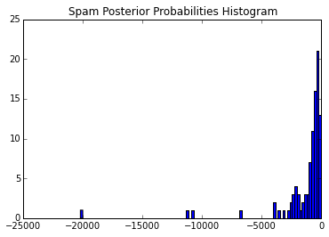

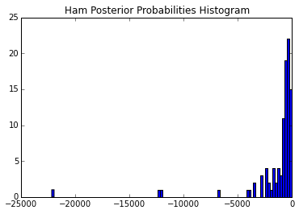

```python
import matplotlib.pyplot as plt #

#read results of mapreduce job
results = open('hw2-4results', "r")

spam_log_posterior_probabilities = [] #keep list of p_spam probabilities for histogram
ham_log_posterior_probabilities = [] #keep list of p_ham probabilities for histogram

sp = []
hp = []

for line in results.readlines():
    result=line.split("\t")
    if result[0] == 'error rate':
        print 'error rate:', result[1]
    elif result[0] == 'spam zero probability count':
        print 'spam zero probability count:', result[1]
    elif result[0] == 'ham zero probability count':
        print 'ham zero probability count:', result[1]
    elif result[0] == 'spam_log_posterior_probabilities':
        spam_log_posterior_probabilities = result[1]
    elif result[0] == 'ham_log_posterior_probabilities':
        ham_log_posterior_probabilities = result[1]

spam_log_posterior_probabilities = spam_log_posterior_probabilities.strip()
spam_log_posterior_probabilities = spam_log_posterior_probabilities.strip('[')
spam_log_posterior_probabilities = spam_log_posterior_probabilities.strip(']')
spam_log_posterior_probabilities = spam_log_posterior_probabilities.split(',')
for value in spam_log_posterior_probabilities:
    sp.append(float(value))
ham_log_posterior_probabilities = ham_log_posterior_probabilities.strip()
ham_log_posterior_probabilities = ham_log_posterior_probabilities.strip('[')
ham_log_posterior_probabilities = ham_log_posterior_probabilities.strip(']')
ham_log_posterior_probabilities = ham_log_posterior_probabilities.split(',')
for value in ham_log_posterior_probabilities:
    hp.append(float(value))

plt.hist(sp, bins=100)
plt.title("Spam Posterior Probabilities Histogram")
plt.show()

plt.hist(hp, bins=100)
plt.title("Ham Posterior Probabilities Histogram")
plt.show()
```

```python
#HW 2.6 - MNB Benchmark
from sklearn.naive_bayes import MultinomialNB
import re
import numpy as np

training_data = []
training_labels = []

WORD_RE = re.compile(r"[\w']+") # compile regex to easily parse complete words

emails = open('enronemail_1h.txt', 'r')
for line in emails:
    fields=line.split('\t') # parse line into separate fields
    if len(fields) == 4: #check if email data formatted correctly
        subject_and_body=" ".join(fields[-2:]).strip()# parse the subject and body fields from the line, and combine into one string
        words=re.findall(WORD_RE,subject_and_body) # create list of words
        training_data.append(words)
        training_labels.append(fields[1])

training_data = np.asarray(training_data)
training_labels = np.asarray(training_labels)

print training_data

MultinomialNB_Classifier = MultinomialNB()
MultinomialNB_Classifier.fit(training_data, training_labels)

#not sure how to train the classifier
```

[output not shown]

[output cut: 81 more lines]

[output not shown]